# main

Marco Hui

2022-10-10

## Set up

I decided against accessing data via an API endpoint because that is limited to 500000 rows per call.

## Exploratory data analysis

A glimpse of the data.

```
## # A tibble: 6 × 19
##   ARREST_KEY ARREST_DATE PD_CD PD_DESC       KY_CD OFNS_DESC LAW_CODE LAW_CAT_CD
##        <dbl> <date>      <dbl> <chr>         <dbl> <chr>     <chr>    <chr>
## 1  236791704 2021-11-22    581 <NA>             NA <NA>      PL 2225… M
## 2  237354740 2021-12-04    153 RAPE 3          104 RAPE      PL 1302… F
## 3  236081433 2021-11-09    681 CHILD, ENDAN…   233 SEX CRIM… PL 2601… M
## 4  192799737 2019-01-26    177 SEXUAL ABUSE    116 SEX CRIM… PL 1306… F
## 5  193260691 2019-02-06     NA <NA>             NA <NA>      PL 2203… F
## 6  237291769 2021-12-03    579 <NA>             NA <NA>      PL 2224… F
## # … with 11 more variables: ARREST_BORO <chr>, ARREST_PRECINCT <dbl>,
## #   JURISDICTION_CODE <dbl>, AGE_GROUP <chr>, PERP_SEX <chr>, PERP_RACE <chr>,
## #   X_COORD_CD <dbl>, Y_COORD_CD <dbl>, Latitude <dbl>, Longitude <dbl>,
## #   Lon_Lat <chr>
```

Shape of the data

```
## [1] 850548     19
```

Some summary statistics of the columns.

```
##    ARREST_KEY         ARREST_DATE             PD_CD       PD_DESC
##  Min.   :173129257   Min.   :2018-01-01   Min.   :  0   Length:850548
##  1st Qu.:189510632   1st Qu.:2018-11-02   1st Qu.:117   Class :character
##  Median :203923924   Median :2019-10-19   Median :397   Mode  :character
##  Mean   :207427106   Mean   :2020-01-10   Mean   :435
##  3rd Qu.:226020361   3rd Qu.:2021-03-23   3rd Qu.:705
##  Max.   :247417454   Max.   :2022-06-30   Max.   :997
##                                           NA's   :395
##      KY_CD        OFNS_DESC           LAW_CODE          LAW_CAT_CD
##  Min.   :101.0   Length:850548      Length:850548      Length:850548
##  1st Qu.:117.0   Class :character   Class :character   Class :character
##  Median :340.0   Mode  :character   Mode  :character   Mode  :character
##  Mean   :255.9
##  3rd Qu.:344.0
##  Max.   :995.0
##  NA's   :1528
##  ARREST_BORO        ARREST_PRECINCT  JURISDICTION_CODE  AGE_GROUP
##  Length:850548      Min.   :  1.00   Min.   : 0.000    Length:850548
##  Class :character   1st Qu.: 40.00   1st Qu.: 0.000    Class :character
##  Mode  :character   Median : 61.00   Median : 0.000    Mode  :character
##                     Mean   : 62.65   Mean   : 1.662
##                     3rd Qu.:100.00   3rd Qu.: 0.000
##                     Max.   :123.00   Max.   :97.000
##
##    PERP_SEX          PERP_RACE           X_COORD_CD        Y_COORD_CD
##  Length:850548      Length:850548      Min.   : 913512   Min.   :121131
##  Class :character   Class :character   1st Qu.: 991330   1st Qu.:185664
##  Mode  :character   Mode  :character   Median :1004788   Median :206772
##                                        Mean   :1005252   Mean   :208188
##                                        3rd Qu.:1017228   3rd Qu.:236071
##                                        Max.   :1067302   Max.   :271820
##
##     Latitude       Longitude        Lon_Lat
##  Min.   :40.50   Min.   :-74.25   Length:850548
##  1st Qu.:40.68   1st Qu.:-73.97   Class :character
##  Median :40.73   Median :-73.93   Mode  :character
##  Mean   :40.74   Mean   :-73.92
##  3rd Qu.:40.81   3rd Qu.:-73.88
##  Max.   :40.91   Max.   :-73.70
##
```

Fewer arrests towards the end of the year. This might be because less people are out in public during the cold winter months.

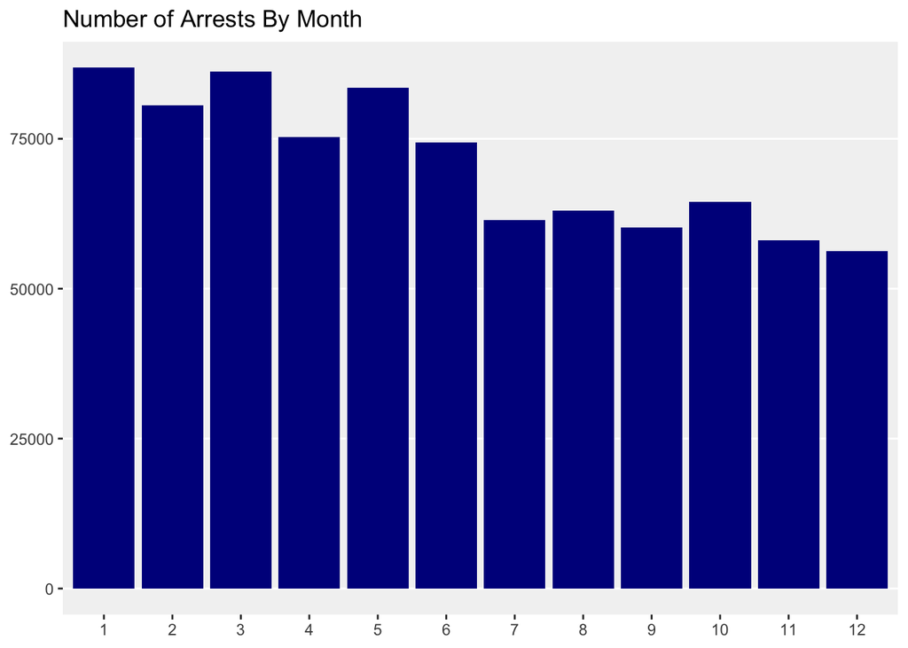

Fewer arrests in Staten Island and Queens. This might be because of their smaller population.

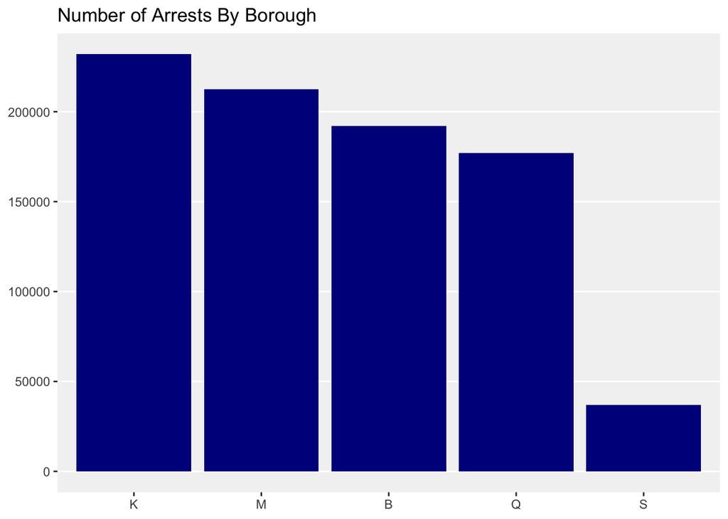

More arrests involving perpetrators who are 25-44 years old, males, and black.

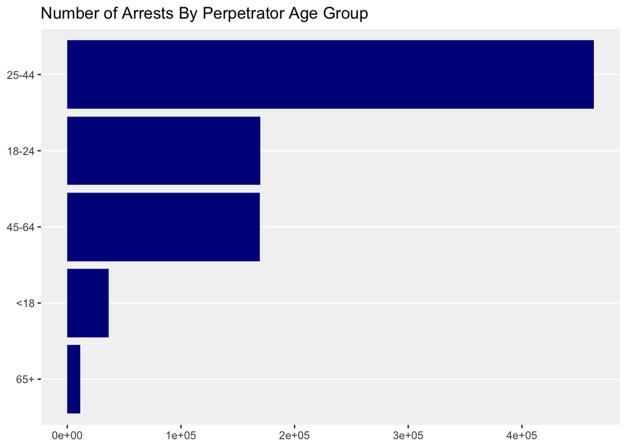

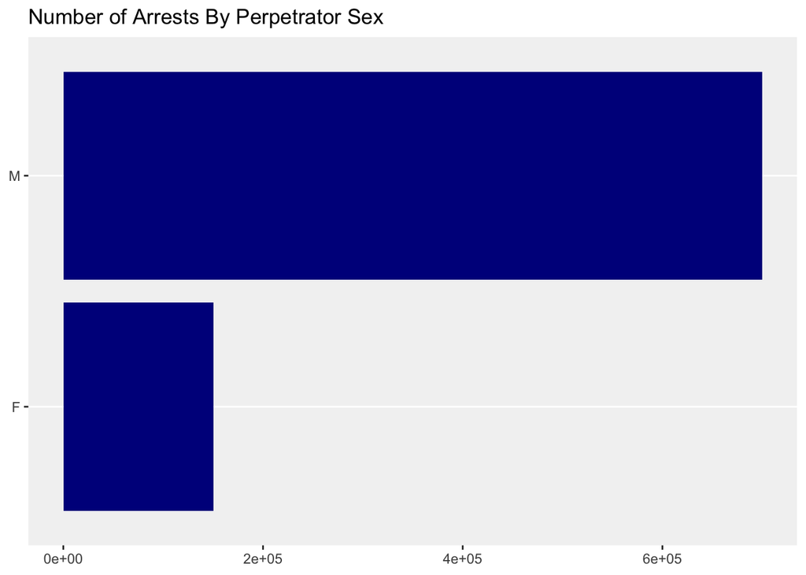

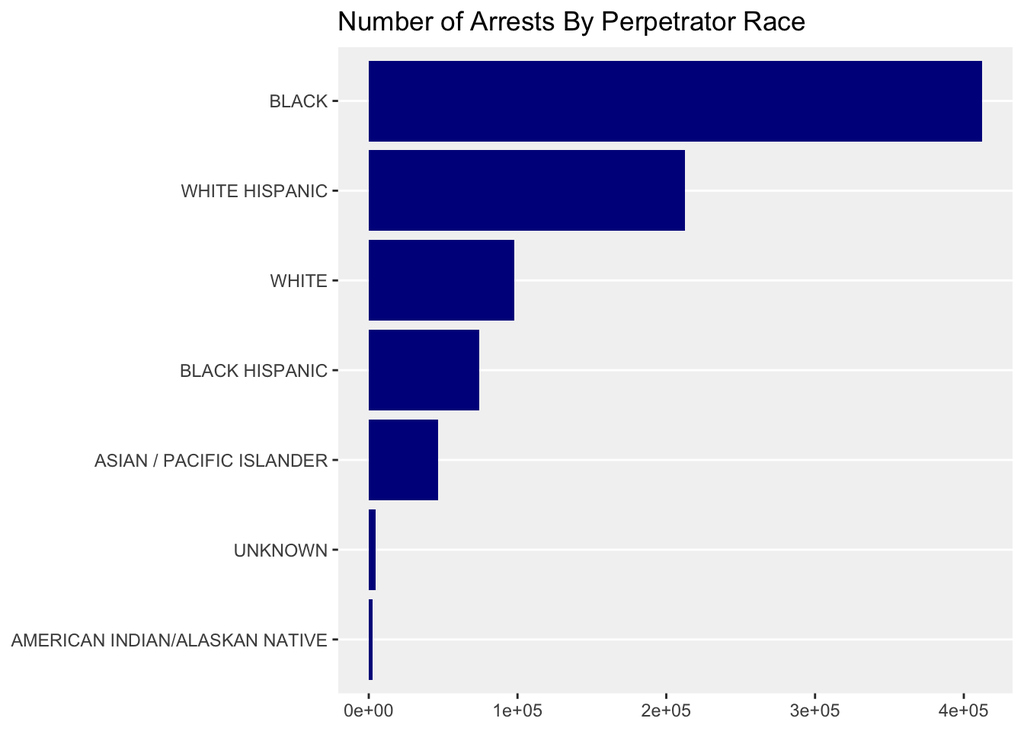

## Has the arrest rate been decreasing from 2018-2022?

Arrests count demonstrates a downwards trend from 2018 to 2022. However, it is difficult to use the 2022 number for comparison because data is incomplete (records stop at July 2022).

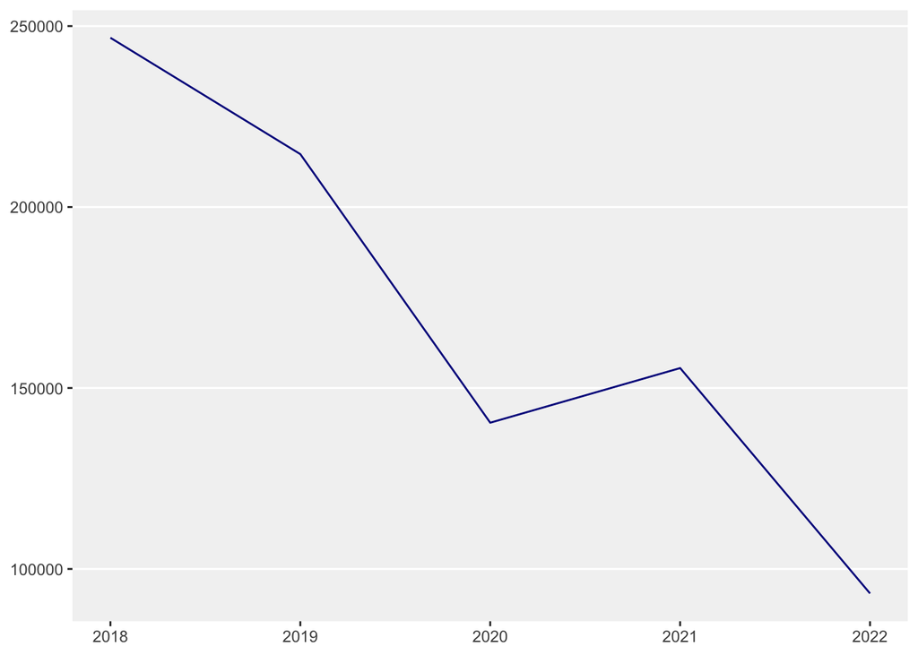

Average monthly arrests per year.

```
## # A tibble: 5 × 2
##    year    avg
##   <dbl>  <dbl>
## 1  2018 20564.
## 2  2019 17885.
## 3  2020 11701.
## 4  2021 12959.
## 5  2022 15540.
```

A breakdown of months and year provides a better picture with more nuances and addresses previous limitation of incomplete data. We see a general downwards trend, dipping during COVID-19 and rising back up slightly in recent months.

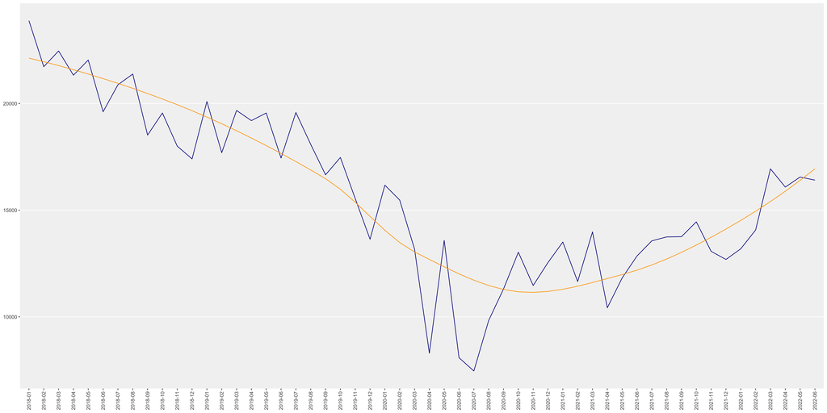

Focusing on just data prior to the COVID19 pandemic in March 2020, the downward trend of arrests is more evident.

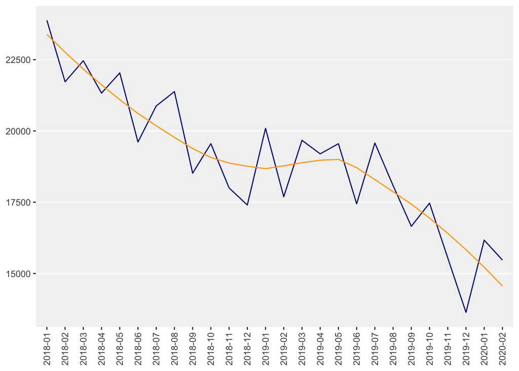

## What are the top 5 most frequent arrests as described in the column ‘pd_desc’ in 2018-2022?

Comparing the count of distinct values for OFNS_DESC and PD_DESC. The latter has significantly more.

```
## # A tibble: 85 × 3
##    OFNS_DESC                       count  pcnt
##    <chr>                           <int> <dbl>
##  1 ASSAULT 3 & RELATED OFFENSES   132294 0.156
##  2 DANGEROUS DRUGS                 80660 0.095
##  3 PETIT LARCENY                   79573 0.094
##  4 FELONY ASSAULT                  68583 0.081
##  5 MISCELLANEOUS PENAL LAW         50033 0.059
##  6 VEHICLE AND TRAFFIC LAWS        46252 0.054
##  7 ROBBERY                         38918 0.046
##  8 GRAND LARCENY                   37580 0.044
##  9 DANGEROUS WEAPONS               35390 0.042
## 10 CRIMINAL MISCHIEF & RELATED OF  32694 0.038
## # … with 75 more rows
```

```
## # A tibble: 393 × 3
##    PD_DESC                                    count  pcnt
##    <chr>                                      <int> <dbl>
##  1 ASSAULT 3                                  99757 0.117
##  2 LARCENY,PETIT FROM OPEN AREAS,             56001 0.066
##  3 ASSAULT 2,1,UNCLASSIFIED                   51694 0.061
##  4 TRAFFIC,UNCLASSIFIED MISDEMEAN             40527 0.048
##  5 ROBBERY,OPEN AREA UNCLASSIFIED             29773 0.035
##  6 PUBLIC ADMINISTRATION,UNCLASSI             25567 0.03
##  7 LARCENY,GRAND FROM OPEN AREAS, UNATTENDED  23434 0.028
##  8 LARCENY,PETIT FROM OPEN AREAS,UNCLASSIFIED 23405 0.028
##  9 CONTROLLED SUBSTANCE, POSSESSI             21075 0.025
## 10 MENACING,UNCLASSIFIED                      19299 0.023
## # … with 383 more rows
```

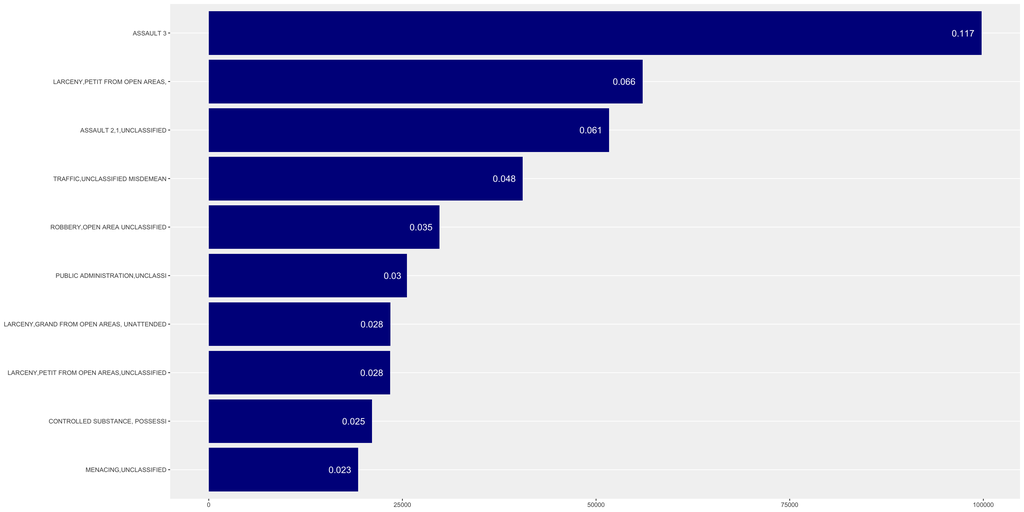

Top 5 most frequent arrests trends over time.

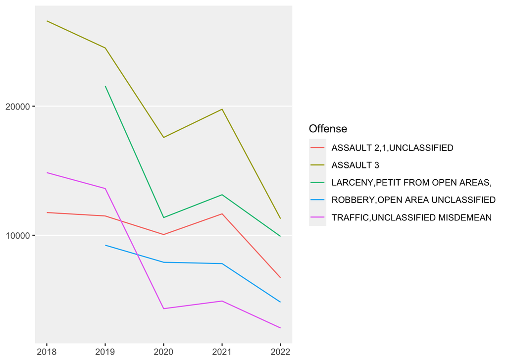

Top 5 most frequent arrests by year. Some changes but not too different year over year. Interesting to see traffic arrests disappearing.

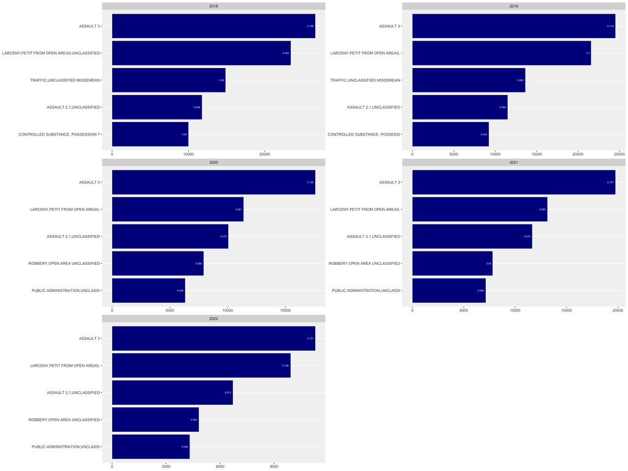

## If we think of arrests as a sample of total crime, is there more crime in precinct 19 (Upper East Side) than precinct 73 (Brownsville)?

In total, there are more crime by count in Brownsville than in Upper East Side

```
## # A tibble: 2 × 3
##   ARREST_PRECINCT count   pcnt
##             <dbl> <int>  <dbl>
## 1              73 17058 0.0201
## 2              19  8871 0.0104
```

Monthly arrest counts in precinct 73 is higher and much more variable.

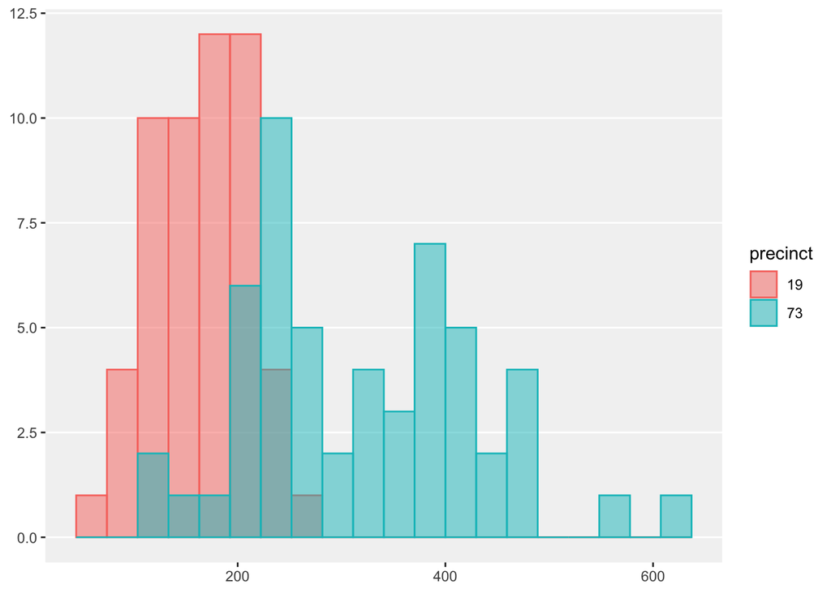

Arrest count in the precincts over time. Arrests in precinct 73 shows more of a downwards trends in comparison to precinct 19.

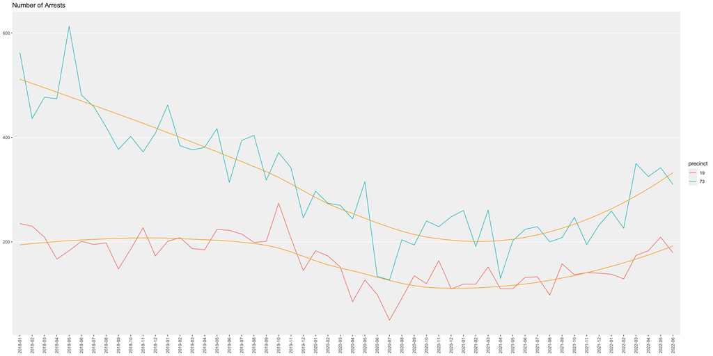

[output not shown]